# Flexible Damage Functions

Author

James Rising, Sebastian Cadavid Sanchez, Climate Impact Lab

Published

April 30, 2026

## 0.1 Agriculture: Rice

Flexible damage function parameters at the Impact Region level.

**Change in rice yields (log change in yields) under full adaptation**

**Outcome units:** `physical`

$$D_{it} = (\alpha_i T_t + \beta_i T_t^2) \cdot Y_{it}^{\gamma}$$

where $\gamma$ is the income elasticity (fitted globally), $\alpha_i$ is the linear coefficient, and $\beta_i$ is the quadratic coefficient.

# 1 Global Estimation

## 1.1 Income Elasticity Estimation

The income elasticity $\gamma$ is estimated using a fixed-effects regression:

$$y_{it} = \gamma \cdot \log(Y_{it}) + \mu_{g(i,T)} + \nu_t + \varepsilon_{it}$$

where $\mu_{g(i,T)}$ are region-by-temperature-bin fixed effects and $\nu_t$ are year fixed effects.

Table 1: Income Elasticity (Gamma) Estimation Results

| Statistic | Value |
| --- | --- |
| Income elasticity ($\gamma$) | 0.0694 |
| Standard error | 1.99e-03 |
| 95% CI | [0.0655, 0.0733] |
| R-squared | 0.9641 |
| Observations | 24,681,159 |
| Regions | 24,326 |
| Gamma quantiles | 19 |

# 2 Parameter Distributions

## 2.1 8-Panel Summary

Row 1: gamma, alpha, beta, rsqr1. Row 2: rho, zeta, eta, rsqr2.

```
Using median gamma: 0.069429, 24,326 rows (of 462,194 total)
```

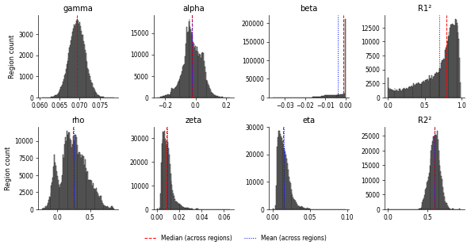

Figure 1: Distribution of Regional Parameters

## 2.2 Projection Equation and Parameter Definitions

The estimated parameters are used to project damages via Monte Carlo sampling:

$$D_{it}^k = (\hat{\alpha}_{ik} T_t + \hat{\beta}_{ik} T_t^2) Y_{it}^{\hat{\gamma}_k} + \hat{\theta}_{ik} T_t Y_{it}^{\hat{\gamma}_k} + \hat{\phi}_{it}^k$$

where $k$ indexes the Monte Carlo draw. The parameters in each row of the output CSV control distinct components of this equation:

- **gamma**: income elasticity $\hat{\gamma}_k$, one of 19 quantile values drawn from $N(\hat{\gamma}, SE(\hat{\gamma}))$
- **alpha, beta**: linear and quadratic temperature coefficients; $\hat{\alpha}_{ik}$ and $\hat{\beta}_{ik}$ are drawn from the joint normal defined by the VCV below
- **sigma11, sigma12, sigma22**: variance-covariance matrix of $(\alpha, \beta)$, used for joint uncertainty sampling
- **rho**: correlation between regional and global polynomial residuals $\rho_i$, used to maintain spatial covariance across regions in Monte Carlo draws
- **zeta**: temperature-dependent error scale $\zeta_{ik}$; the run-specific error term $\hat{\theta}_{ik}$ is drawn from $N(0, \zeta_{ik})$
- **eta**: residual noise standard deviation $\eta_{ik}$; the annual noise $\hat{\phi}_{it}^k$ is drawn from $N(0, \eta_{ik})$
- **rsqr1, rsqr2**: polynomial fit quality and error model fit, respectively

## 2.3 Summary Statistics

Table 2: Regional Parameter Summary

| Parameter | Mean | Median | Std | Min | Max | N |
| --- | --- | --- | --- | --- | --- | --- |
| alpha | -0.02073 | -0.02374 | 0.06025 | -0.2421 | 0.2158 | 24,326 |
| beta | -0.003693 | -0.0011 | 0.004856 | -0.03491 | 0 | 24,326 |
| rho | 0.251 | 0.2422 | 0.1955 | -0.2358 | 0.869 | 24,312 |
| zeta | 0.009293 | 0.008274 | 0.005262 | 0 | 0.0642 | 24,326 |
| eta | 0.01553 | 0.01405 | 0.007986 | 0 | 0.09576 | 24,326 |
| rsqr1 | 0.6986 | 0.7894 | 0.2485 | 0 | 0.989 | 24,326 |
| rsqr2 | 0.5934 | 0.5952 | 0.06832 | 0 | 0.9236 | 24,326 |

# 3 Spaghetti Curves

Regional damage function curves showing D(T) = αT + βT² for sampled regions.

[interactive chart not shown]

Figure 2: Regional Damage Functions

# 4 Zero Crossings

The zero crossing (extremum) of the parabola occurs at $T^* = -\alpha / (2\beta)$.

Table 3: Zero Crossing Statistics

| Category | Count | Percentage |
| --- | --- | --- |
| β = 0 (no crossing) | 10600 | 43.6% |
| T > 20°C (beyond graph) | 222 | 0.9% |
| T < 0°C (negative crossing) | 5922 | 24.3% |
| Valid crossings (0-20°C) | 7582 | 31.2% |

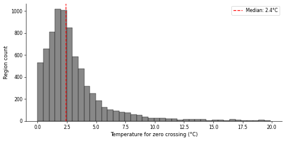

Figure 3: Distribution of Zero Crossing Temperatures

# 5 Slope Analysis

Maximum slope between 0 and 10°C: $\frac{dM}{dT} = \alpha + 2\beta T$

The maximum occurs at either T=0 or T=10 (endpoints of interval).

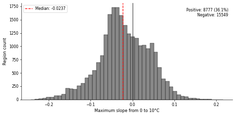

Figure 4: Distribution of Maximum Slopes (0-10°C)

*Convexity analysis omitted (beta constraint active).*

# 6 R-squared Analysis

## 6.1 Polynomial Fit Quality (rsqr1)

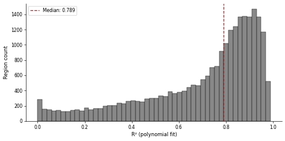

Figure 5: Regional Fit Quality (R-squared)

## 6.2 Error Model R-squared (rsqr2) Quantiles

Table 4: rsqr2 Quantiles

| 0% (Min) | 25% | 50% (Median) | 75% | 100% (Max) |
| --- | --- | --- | --- | --- |
| 0.0000 | 0.5498 | 0.5952 | 0.6375 | 0.9236 |

# 7 Modelled Variance

Modelled variance statistic: $1 - \frac{\sum_i \eta_i^2}{\sum_i D_i^2}$

Table 5: Modelled Variance Statistics

| Statistic | Value |
| --- | --- |
| Modelled variance | 0.9909 |
| Sum(η²) | 7.4197 |
| Sum(D²) at T=3.0°C | 818.0197 |
| N regions | 24,326 |

# 8 Best- and Worst-Fitting Regions

The 3 worst- and 3 best-fitting regions by R-squared, with raw simulation data overlaid on the fitted polynomial curve. **Red rows = worst fits**, **green rows = best fits**.

Table 6: Best- and worst-fitting regions

Top 3 best fit (R²) Top 3 worst fit (R²)

| Region | α | β | η | R² |
| --- | --- | --- | --- | --- |
| SAU.13 | -0.122 | -6.84e-4 | 0.00791 | 0.989 |
| IRN.10.94 | -0.126 | -0.00187 | 0.00977 | 0.985 |
| TUR.33.R19134d5774320e02 | -0.148 | -9.81e-5 | 0.0116 | 0.985 |
| BRA.21.4288.8401 | 9.03e-4 | -3.12e-4 | 0.0115 | 0.00127 |
| KOR.8.R28b1c7563f23f3aa | 0.0027 | -5.02e-4 | 0.0122 | 0.00142 |
| ARG.4.173 | 0.002 | -4.10e-4 | 0.00829 | 0.00145 |

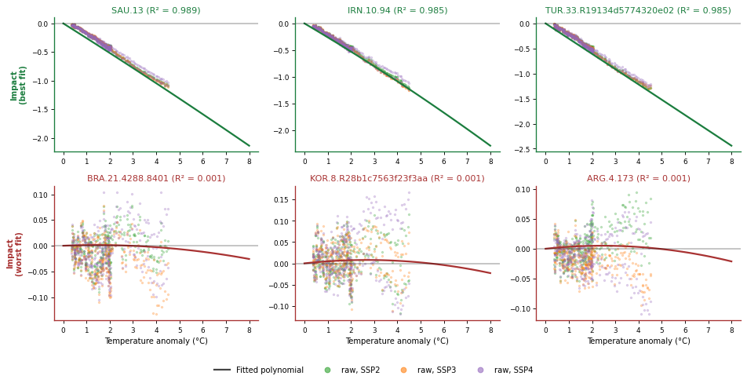

# 9 Regional Parameter Maps

Maps of key parameters at the **impact region** level. Red = negative (damage increases with T), Blue = positive.

## 9.1 Alpha (Linear Coefficient)

Alpha ($\alpha$) represents the linear sensitivity to temperature. Regions with negative alpha experience damage that increases with the first degree of warming.

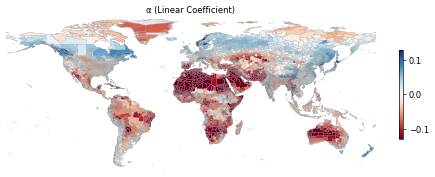

Figure 7: α (linear coefficient)

## 9.2 Beta (Quadratic Coefficient)

Beta ($\beta$) represents the curvature of the damage function.

The concavity ($\beta \leq 0$) constraint is enforced for this sector, meaning optimal temperature exists, damages accelerate beyond it.

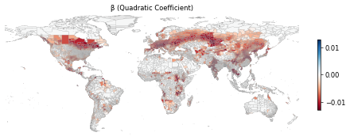

Figure 8: β (quadratic coefficient)

## 9.3 R-squared (Fit Quality)

$R^2$ measures the polynomial fit quality. Higher values indicate that the quadratic form captures more of the variance in the data.

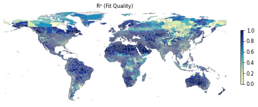

Figure 9: R² (stage 1 fit quality)

# 10 F2: Flex vs Raw Comparison

Comparison of flexible damage function predictions against raw simulation means.

For each scenario (RCP × SSP × Model), we compute at the final year:

- **Flex predicted**: $(\alpha \cdot T + \beta \cdot T^2) \cdot Y^\gamma$
- **Raw actual**: The outcome variable (y) from the source data

**Year 2098**: 292,536 rows

**rcp45**

**SSP2**

**high**

**Correlation:** 0.9296 | **RMSE:** 0.100020 | **Sign agreement:** 93.5%

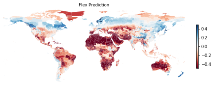

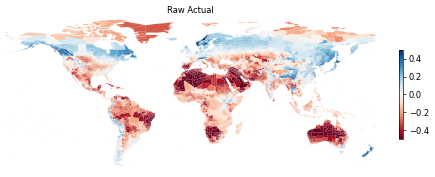

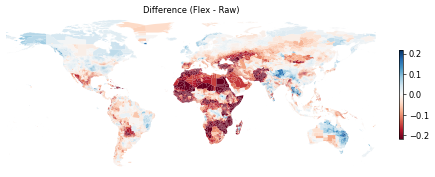

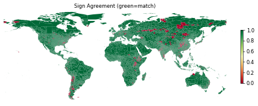

[interactive chart not shown]

Top 5 best predicted Top 5 worst predicted

Year 2098 · T<sub>mean</sub> across these regions: 2.05°C

| Region | Raw | Flex | Residual |
| --- | --- | --- | --- |
| AIA | 0 | 0 | 0 |
| BLM | 0 | 0 | 0 |
| BMU.R676c07148ce9acd1 | 0 | 0 | 0 |
| CCK | 0 | 0 | 0 |
| CXR | 0 | 0 | 0 |
| SDN.6.16.74.227 | -0.291 | -0.976 | -0.685 |
| MLI.4.15 | -0.155 | -0.773 | -0.618 |
| SDN.6.15.72.222 | -0.259 | -0.861 | -0.602 |
| HND.11 | -0.194 | -0.769 | -0.575 |
| SDN.6.15.73.224 | -0.476 | -1.05 | -0.572 |

**low**

**Correlation:** 0.9527 | **RMSE:** 0.081901 | **Sign agreement:** 94.4%

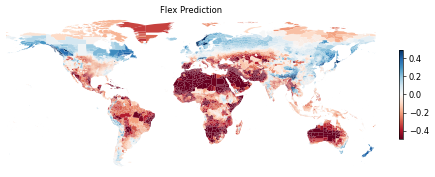

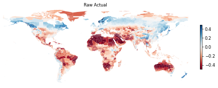

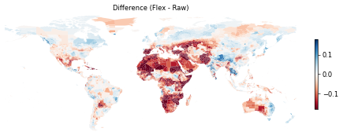

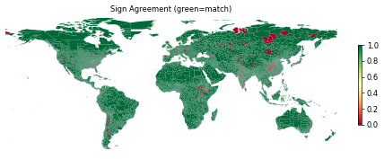

[interactive chart not shown]

Top 5 best predicted Top 5 worst predicted

Year 2098 · T<sub>mean</sub> across these regions: 2.05°C

| Region | Raw | Flex | Residual |
| --- | --- | --- | --- |
| AIA | 0 | 0 | 0 |
| BLM | 0 | 0 | 0 |
| BMU.R676c07148ce9acd1 | 0 | 0 | 0 |
| CCK | 0 | 0 | 0 |
| CXR | 0 | 0 | 0 |
| AFG.22.231 | -0.435 | -0.909 | -0.474 |
| AFG.22.233 | -0.424 | -0.877 | -0.453 |
| SDN.6.16.74.227 | -0.484 | -0.937 | -0.453 |
| MLI.4.15 | -0.28 | -0.731 | -0.451 |
| AFG.22.R8dc821211617773c | -0.39 | -0.838 | -0.448 |

**SSP3**

**high**

**Correlation:** 0.9483 | **RMSE:** 0.074326 | **Sign agreement:** 94.1%

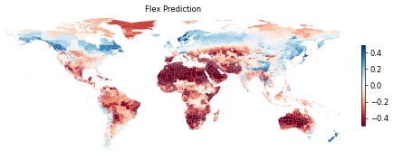

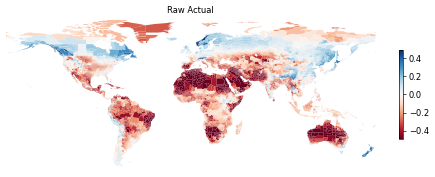

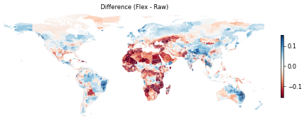

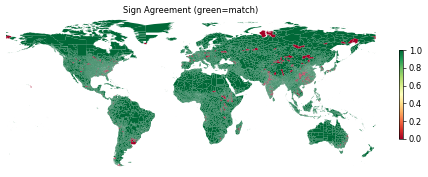

[interactive chart not shown]

Top 5 best predicted Top 5 worst predicted

Year 2098 · T<sub>mean</sub> across these regions: 2.05°C

| Region | Raw | Flex | Residual |
| --- | --- | --- | --- |
| AIA | 0 | 0 | 0 |
| BLM | 0 | 0 | 0 |
| BMU.R676c07148ce9acd1 | 0 | 0 | 0 |
| CCK | 0 | 0 | 0 |
| CXR | 0 | 0 | 0 |
| ZWE.10.56 | -0.175 | -0.579 | -0.404 |
| ZWE.9.R19a261b63a503c9c | -0.184 | -0.577 | -0.393 |
| ZWE.8.Raef3712f385d02bc | -0.172 | -0.565 | -0.393 |
| ZWE.10.R6a51f20fce9a50e9 | -0.182 | -0.573 | -0.391 |
| ZWE.7.35 | -0.172 | -0.562 | -0.39 |

**low**

**Correlation:** 0.9587 | **RMSE:** 0.067301 | **Sign agreement:** 93.8%

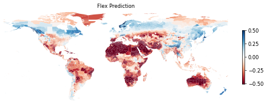

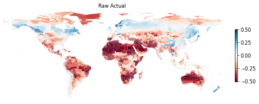

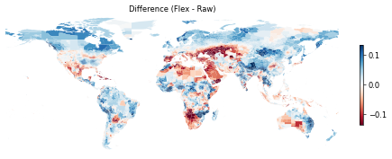

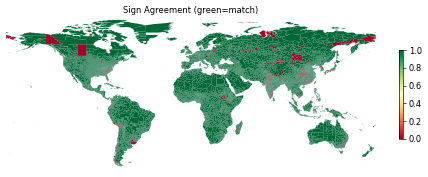

[interactive chart not shown]

Top 5 best predicted Top 5 worst predicted

Year 2098 · T<sub>mean</sub> across these regions: 2.05°C

| Region | Raw | Flex | Residual |
| --- | --- | --- | --- |
| AIA | 0 | 0 | 0 |
| BLM | 0 | 0 | 0 |
| BMU.R676c07148ce9acd1 | 0 | 0 | 0 |
| CCK | 0 | 0 | 0 |
| CXR | 0 | 0 | 0 |
| ZWE.6.29 | -0.688 | -0.234 | 0.453 |
| ZWE.4.R10448490b274a672 | -0.726 | -0.29 | 0.436 |
| ZWE.5.R5d668dc7ff81991f | -0.756 | -0.33 | 0.426 |
| ZWE.4.R960bd0af211ee36f | -0.658 | -0.239 | 0.419 |
| ZWE.10.54 | -0.688 | -0.27 | 0.418 |

**SSP4**

**high**

**Correlation:** 0.9486 | **RMSE:** 0.076233 | **Sign agreement:** 93.4%

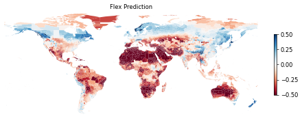

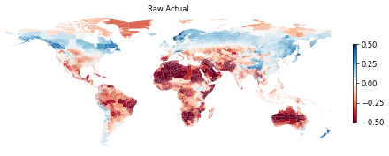

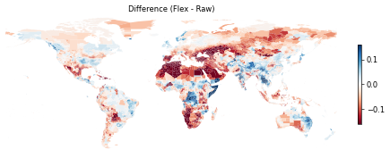

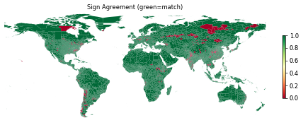

[interactive chart not shown]

Top 5 best predicted Top 5 worst predicted

Year 2098 · T<sub>mean</sub> across these regions: 2.05°C

| Region | Raw | Flex | Residual |
| --- | --- | --- | --- |
| AIA | 0 | 0 | 0 |
| BLM | 0 | 0 | 0 |
| BMU.R676c07148ce9acd1 | 0 | 0 | 0 |
| CCK | 0 | 0 | 0 |
| CXR | 0 | 0 | 0 |
| MAR.12.38.287.977 | -0.201 | -0.668 | -0.468 |
| MAR.Re84a505a9b0896c1 | -0.328 | -0.783 | -0.455 |
| MAR.10.32.244.R0e00e1dc597eabb5 | -0.369 | -0.809 | -0.44 |
| MAR.14.50.362.1350 | -0.26 | -0.687 | -0.426 |
| MAR.14.48.354.1321 | -0.251 | -0.659 | -0.408 |

**low**

**Correlation:** 0.9600 | **RMSE:** 0.068115 | **Sign agreement:** 93.5%

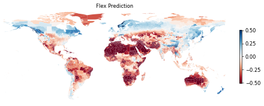

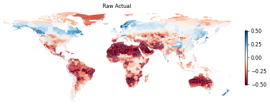

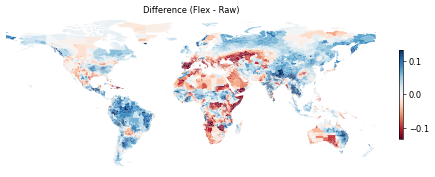

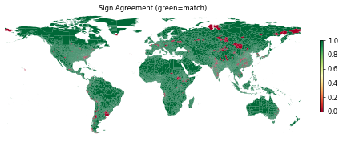

[interactive chart not shown]

Top 5 best predicted Top 5 worst predicted